# A workspace-based analysis of adjuncts

Dan Milway

LSA dry-run - 6 December 2019

# Overview

**(P1)**

Adjuncts are best characterized as syntactically invisible/vacuous subexpressions

**(P2)**

This can be formalized if adjuncts are not attached to their "hosts", but derived in parallel with those "hosts"

**(P3)**

This formalization predicts a number of secondary properties of adjuncts.

## Plan

1. Divide properties of adjuncts into primary and secondary.
2. Argue for (P1) using the primary properties of adjuncts as evidence
3. Sketch out (P2) in workspace-theoretic terms
4. Argue for (P3).
5. Discuss some open questions that my proposal raises.

# Primary/Secondary properties of Adjuncts

- Adjuncts have a number of properties:
- Freely ordered
1. 1. Sadie sang the song with gusto after dinner.
   2. Sadie sang the song after dinner with gusto.
   - Optional
2. 1. Sadie sang the song with gusto.
   2. Sadie sang the song.
   - Stackable
3. 1. Sadie sang the song with gusto.
   2. Sadie sang the song with gusto after dinner.
   - Islands
4. *Who did Sadie invite Violet without meeting __<sub>wh</sub>?
   - (but parasitic gaps)
5. Who did Sadie invite __<sub>wh</sub> without meeting __<sub>PG</sub>?
   - Conjunctive interpretation
   - ...
- There's an intuitive difference between the first three properties and the remainder.
- The first three are somehow *essential* properties of adjuncts.
  - These are the **primary properties**.
- The remainder are things we discovered later.
  - These are the **secondary properties**.
- This dichotomy suggests a method of theorizing:
- Start by constructing a theory that *explicitly* captures the primary properties,
- Then test that theory against the secondary properties.

# Developing a theory of adjuncts

- Adjuncts are:
1. Freely ordered
2. Optional
3. Stackable
- Can we get these down to a single property?
6. 1. Sadie [sang the song]<sub>$\alpha$</sub>.
   2. Sadie [[sang the song]<sub>$\alpha$</sub> with gusto]<sub>$\beta$</sub>.
   3. Sadie [[[sang the song]<sub>$\alpha$</sub> with gusto]<sub>$\beta$</sub> after dinner]<sub>$\gamma$</sub>.
   4. Sadie [[[sang the song]<sub>$\alpha$</sub> after dinner]<sub>$\delta$</sub> with gusto]<sub>$\zeta$</sub>.
- These examples are equally grammatical.
- Beyond that, the labeled expressions are *syntactically equivalent* to each other.
  - If $\alpha, \beta, \gamma, \delta$, and $\zeta$ are all VPs, selected by, say, T, then any version of T that selects $\alpha$ will also select the other labeled VPs.
  - *cf* specifiers/complements
7. 1. Joe hit the pillow.
   2. * Joe hit.
8. 1. I believe Omar ate the pizza.
   2. *I believe ate the pizza.
- If a host-adjunct expression H<sup>$\frown$</sup>A is grammatically equivalent to its host H, then the adjunct must be syntactically vacuous.
  - (P1)
  - H<sup>$\frown$</sup>A $\equiv$<sub>$\sigma$</sub> H

# Formalizing (P1) in derivational minimalism

- the core of derivational minimalism:
- Phrases and sentences are derived by successive application of Merge.
9. Merge(X, Y) $\rightarrow$ {X, Y}
- The output of Merge is an expression distinct from its inputs.
  - {X, Y} $\not{\equiv}$<sub>$\sigma$</sub> X $\not{\equiv}$<sub>$\sigma$</sub> Y
- Merge is not a good candidate for adjuncts, given (P1)
- Previous accounts introduce complications to the grammar to allow for adjuncts:
- A new operation (Chomsky 2004)
- An extra cycle of syntax (Stepanov 2001; Lebeaux 1991)
- But adjunction is optional

**Conjecture**

Any concept/thought expressed by a phrase/sentence with adjuncts can be expressed by a set of sentences/phrases without adjuncts.

- General considerations of theoretical parsimony militate against adding anything to our theory that we don't absolutely need.
- Instead, we'll make do with mechanisms we would need anyway:
- Deletion of redundant structure
- Workspaces

## Deletion

- I will make the now-standard assumption that long-distance dependencies are created by merging single phrases in multiple positions.
- Copy theory of movement
- Only one "copy" of the phrase is pronounced.
- The others must be deleted.
10. 1. **Derived structure**  
       {{The cake}{was eaten {the cake}}}
    2. **Delete copies**  
       {{The cake} {was eaten {the cake}}}
    3. **Pronounce**  
       The cake was eaten.
- Deletion seems to be governed by two factors:
1. Identity
   - If two structures are identical, delete one.
2. (Asymmetric) C-command Generally, delete the structurally lower phrase.  
   (See Trinh (2009) for more details)

## Workspaces

- Recent discussions of derivational minimalism have included the notion of *workspaces* (Collins and Stabler 2016; Chomsky 2019)
- Generally, workspaces capture the intuition that arguments (usually NPs/DPs) are derived separately from the clausal spine.
11. Deriving *The 5 girls sang the anthem*
    1. Derive *the anthem* in workspace 1
    2. Derive *the 5 girls* in workspace 2
    3. Derive the entire clause in workspace 3, which includes the result of 1 and 2
- Individual workspaces are encapsulated
- The domain of Merge is the workspace
- If a phrase is being derived in a workspace, all of its constituents must be included in that workspace.
12. WS1: <*the*, *girls*>  
    WS2: <*the*, *anthem*>
    1. Merge(*the*, *girls*) $\rightarrow$ <{*the*, *girls*}>, <*the*, *anthem*>
    2. Merge(*girls*, *anthem*) $\rightarrow$ undefined

## The theory of adjuncts

### First pass

- Adjuncts derived in separate workspaces which are never merged with their hosts.
- unlike arguments which *are* merged with their predicates.
13. Deriving *The 5 girls sang the anthem with gusto*
    1. Derive *the anthem* in WS1
    2. Derive *the 5 girls* in WS2
    3. Derive *with gusto* in WS3
    4. Derive the entire clause in WS4, which includes the result of 1 and 2
14. <{{*the*, *girls*}, {pst , {*sing*, {*the*, *anthem*}}}}>,  
    <{*with*, *gusto*}>
- The result of this derivation is a pair of expressions, which we can linearize accordingly.
- Problem: Adjuncts seem to have scope
- *The visible visible stars* (Larson 1998)
- *She won't have danced on Sunday*
- Cartography
15. <{*she* {*not* {*will*, {*have* {*dance*}}}}}>,  
    <{*on*, *Sunday*}>
- How can we differentiate the possible scopes of *on Sunday*?

### Second Pass

- Consider how scope is treated in an X-bar theoretic phrase structure:
- an adjunct's scope is its c-command domain
  - A takes B in its scope if A C-commands B

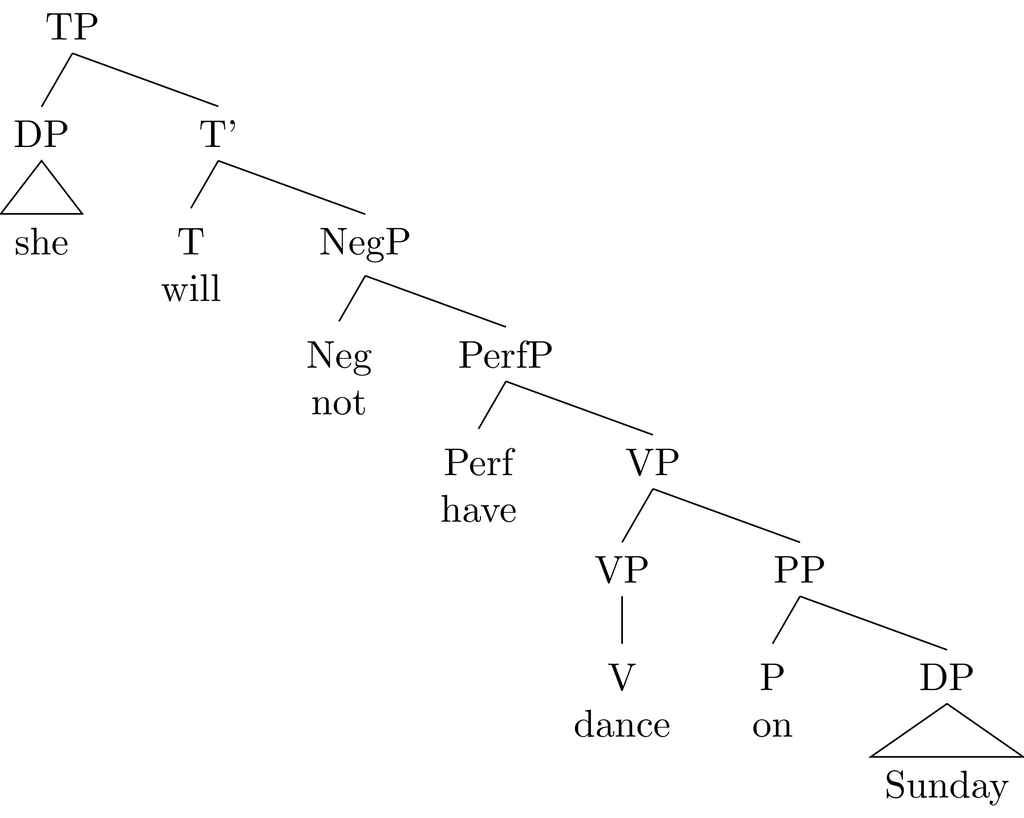

Low scope

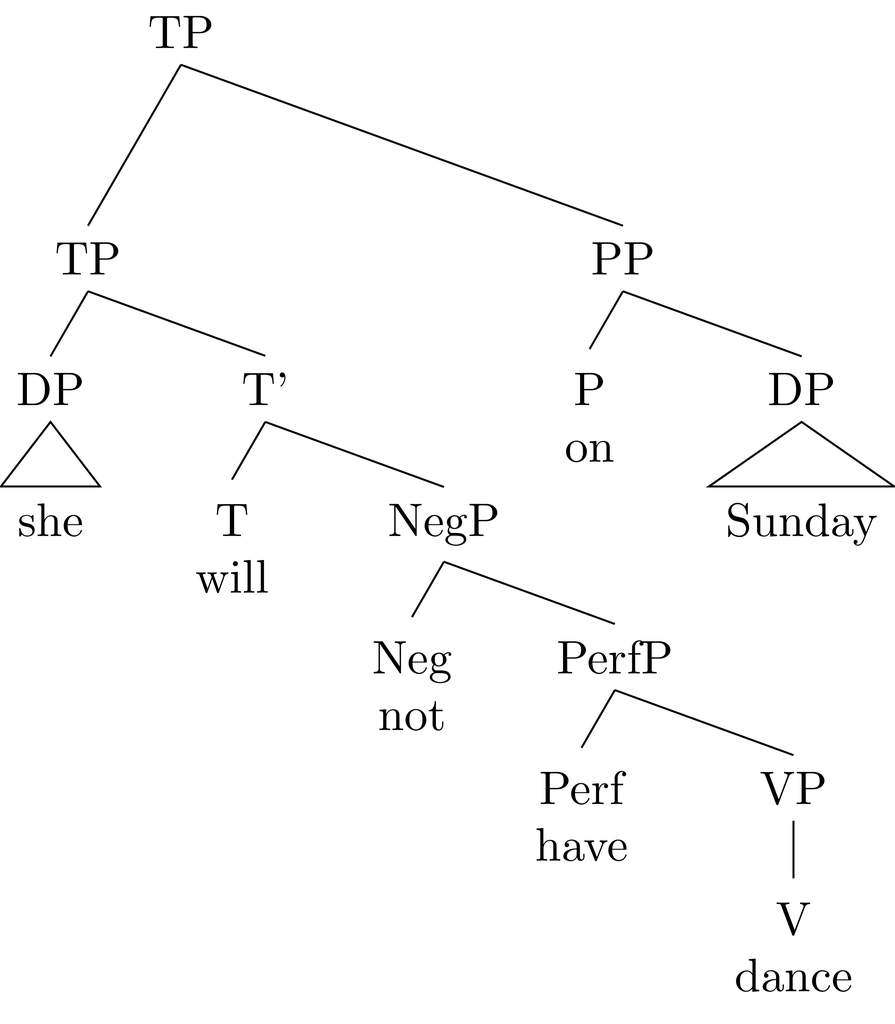

High scope

- Now consider:
16. <{*she* {Neg {T, {Perf {*dance*}}}}}>,  
    <{*she* {Neg {T {Perf {*on*, *Sunday*}}}}}>
- Here, the PP doesn't "scope over" the verb,
- but now the PP and the verb scope under the same nodes
- PP's c-commanders: {*she*, Neg, T, Perf}
- *dance*'s c-commanders: {*she*, Neg, T, Perf}
- How do we derive it?
- The workspaces are independent up to a point ...
  - VP for the host
  - PP for the adjunct
- After this point the two workspaces are derived in lockstep
  - Every operation in one workspace, is mirrored in the other
  - When Merge(Perf, *dance*) occurs, so does Merge(Perf, *on Sunday*), and so on.
- Why don't we pronounce all the stuff above the PP?
- It gets deleted
  - It's identical to the stuff in the host
  - Not c-commanded, but decidedly ordered
  - WS1,WS2 $\not{=}$ WS2,WS1

## Interim Summary

- A Host-adjunct expression is underlyingly a pair of structures.
- Each structure is derived in its own workspace.
- These structures have identical "heads" and distinct "tails".
17. <{*Sadie*, {T, {*sing*, {*the*, *song*}}}}>,  
    <{*Sadie*, {T, {*with*, *gusto*}}}>
- The identical parts of the adjunct is deleted.
18. <{*Sadie*, {T, {*sing*, {*the*, *song*}}}}>,  
    <{*Sadie*, {T, {*with*, *gusto*}}}>
- The workspaces are inherently ordered and this order is respected in pronunciation
- Adjunction is syntactically vacuous because host-adjunct structures don't exist in the syntax.

# Secondary Properties

## Island-hood

- Under this theory, it follows directly from the fact that the domain of Merge is restricted to the workspace.
- In (19) *who* cannot be merged with the host, because it is in a different workspace.
19. 1. *Who did Sadie invite Violet without meeting __<sub>wh</sub>?
2. <{*Who* {C<sub>Q</sub>, {... {*Sadie*, {*invite*, *Violet*}}}}}>,  
   <{C, {... {*without* {*meeting*, *who*}}}}>
- If *who* moves within its workspace, we lose the identity portion of deletion for the adjunct.
20. <{C, {... {*Sadie*, {*invite*, *Violet*}}}}}>,  
    <{*who* {C<sub>Q</sub>, {... {*without* {*meeting*, *who*}}}}>
- This might surface, but not as (19 a)

## Parasitic Gaps

- Parasitic gaps occur when two parallel Wh-movement operations occur in separate workspaces
21. 1. Who did Sadie invite __<sub>wh</sub> without meeting __<sub>wh</sub>?
2. <{*Who* {C<sub>Q</sub>, {... {*Sadie*, {*invite*, *who*}}}}}>,  
   <{who {C<sub>Q</sub>, {... {*without* {*meeting*, *who*}}}}>
- Unlike (19), each *who* stays within its workspace
- Unlike (20), the higher *who* and C<sub>Q</sub> in the adjunct can be deleted.

## Interpreting host-adjunct structures

- Adjunction is (generally) characterized by a conjunctive interpretation.
- Predicate Modification/Event Identification in standard formal semantics.
- In this theory host and adjunct are independent expressions.
- They compose like independent sentences:
22. *The sky is blue.*, *The chair broke*  
    $\rightarrow$ *the sky is blue **and** the chair broke.*
23. <{{*the*, *girls*}, {pst, {*sing*, {*the*, *anthem*}}}}>,  
    <{{*the*, *girls*}, {pst, {*with*, *gusto*}}}>  
    $\rightarrow$ *the girls sang the anthem **and** the girls did so with gusto.*
- If the domain of Predicate Modification is coextensive with host-adjunct structures, then we can eliminate it from our repertoire of compositional operations.

# Conclusions

## The basic proposal

- Host-adjunct expressions are the result of two (or more) expressions being derived in parallel workspaces.
- No new mechanisms
- Workspaces and deletion are needed anyway
- Existing mechanisms are not complicated
- Merge is unchanged.
- Delete is generalized
  - Asymmetric c-command $\rightarrow$ any ordering.
- Naturally predicts adjunct islands, parasitic gaps, predicate modification

## Possible extensions

- Coordination
- Bošković (To Appear) argues that the coordinated structure constraint can be unified with adjunct islands.
- Chomsky (2019) analyzes both as results of pair-merge.
- Ellipsis
- Adjunction:
  - WS1 and WS2 are derived in parallel.
  - Delete the head of WS2
- Ellipsis:
  - WS1 and WS2 are derived in parallel.
  - Delete the tail of WS2?
- Head movement?
- Also often taken to be pair-merge

## Open Questions

- How is lockstep derivation ensured?
- Generate and filter?
- Some mechanism of controlling derivations?
- Non-adjunct "adjuncts"
- Topicalized PPs, AdvPs, *etc*

# References

Bošković, Željko. To Appear. “On Unifying the Coordinate Structure Constraint and the Adjunct Condition.” Edited by A. Bárány, T. Biberauer, J. Douglas, and S. Vikner. Language Science Press. https://boskovic.linguistics.uconn.edu/wp-content/uploads/sites/2801/2019/05/Boskovic_On-Unifying-the-Coordinate-Structure-Constraint-and-the-Adjunct-Condition.pdf.

Chomsky, Noam. 2004. “Beyond Explanatory Adequacy.” In *Structures and Beyond: The Cartography of Syntactic Structures*, 3:104–31. Oxford University Press.

———. 2019. *MIT Lecture on 12 April 2019*. https://www.dropbox.com/s/k1hg1bzpw2uzdoa/2976_Noam_Chomsky_Lecture_4-12.mp4.

Collins, Chris, and Edward Stabler. 2016. “A Formalization of Minimalist Syntax.” *Syntax* 19 (1): 43–78. doi:10.1111/synt.12117.

Larson, Richard K. 1998. “Events and Modification in Nominals.” In *Semantics and Linguistic Theory*, 8:145–68.

Lebeaux, David. 1991. “Relative Clauses, Licensing, and the Nature of the Derivation.” *Syntax and Semantics* 25: 209–39.

Stepanov, Arthur. 2001. “Late Adjunction and Minimalist Phrase Structure.” *Syntax* 4 (2). Wiley Online Library: 94–125.

Trinh, Tue. 2009. “A Constraint on Copy Deletion.” *Theoretical Linguistics* 35 (2-3). Walter de Gruyter GmbH & Co. KG: 183–227.